# Assignment 2 Task 2 Answer Key

Nathan Grimes

1/24/2023

## Task 2: Parameter Estimation with Purrr - Lizards Length to Weight

Source: Lightfoot, D. and W.G. Whitford. 2020. Lizard pitfall trap data from 11 NPP study locations at the Jornada Basin LTER site, 1989-2006 ver 37. Environmental Data Initiative. https://doi.org/10.6073/pasta/4a6e258fb49c31e222ecbbcfd128967f

For task 2, you will use non linear least squares to estimate parameters of a length to weight model for lizard populations in New Mexico.

Create a knitted.html saved as `a2_task2_lastname_firstname.html` which provides a description of the dataset, the purpose of the analysis, a citation of the dataset, and answers the following questions.

1. Create a dataframe of only the sex, species, snout to vent length, and weight. Exclude juveniles from the analysis. Remove any species that possess less than 6 observations. Finally, make sure you “balance” the data between male and female observations (e.g. make sure all species that are selected have observations of both male and female). Show the list of the species that will be used in the rest of the task (can just print out, no need for a table)
2. Fit a snout length to weight model of the following form to all lizard in your clean dataframe.

$$\begin{equation}
W=a(SVL)^b
\end{equation}$$

1. Weight is given by W, snout to vent length by SVL, and a and b are the parameters that need to be fitted. Which strategy would be best to provide an initial guess? We could go with strategy one and look through the literature, but let’s practice our coding and math skills.
2. Since we know the model is exponential in nature, we could log transform the data. If we do a standard OLS regression on the log transformed data, we can get approximations of the parameters from the regression coefficients `my_guess_model <- lm(log_weight ~ log_length, data = my_df)`
3. Using the coefficients function, we can then supply the nls start list with the regression coefficients. Hint: You will have to mathematically transform the intercept coefficient to get the guess for parameter a.

```
## [1] "CNTI" "HOMA" "UTST" "COTE" "SCUN" "CNIN" "PHMO"
```

2. Present your fitted model on a plot with female and male lizards separated by color. You should include the nls model in `kable` output of the html.

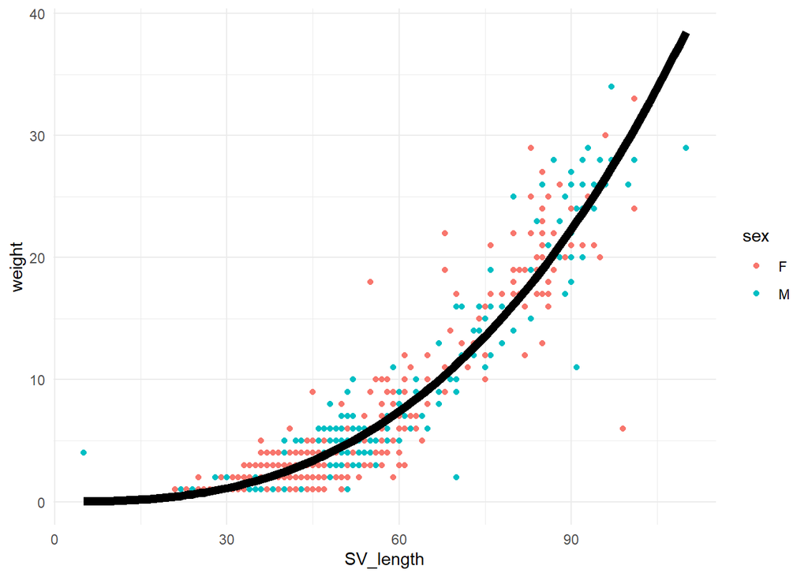

3. Filter out the dataset for male “CNTI” species. Fit an nls model to this subset. Compare the output from the species specific nls model to the general nls model for all species by graphing the model fits on the “CNTI” male data. Report the RMSE for both models in the figure caption. Also in the figure caption briefly discuss which model should be used and why.

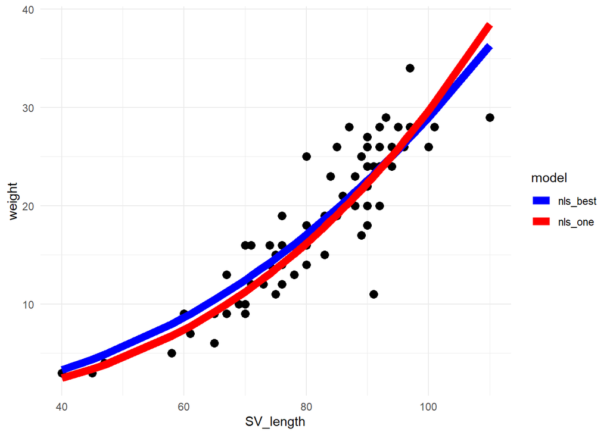

Using the Metrics package I get RMSE of 3.34929 for single species model and 16.4533 for the all species. With modelr the single species model is nearly identical with 3.34929 to the all species nls rmse of 3.46206.

### Optional

4. Group by species and sex then nest the data. Use `map()` variants to parameterize length to weight models for every species separated by each sex. Hint: you may need to adjust the controls of the `nls` function
5. Use the models to predict the data. Calculate the RMSE for each model created in part 3. Make a table showing the RMSE for each model.
6. Create a plot grid showing each species and sexes actual weight and the model prediction.

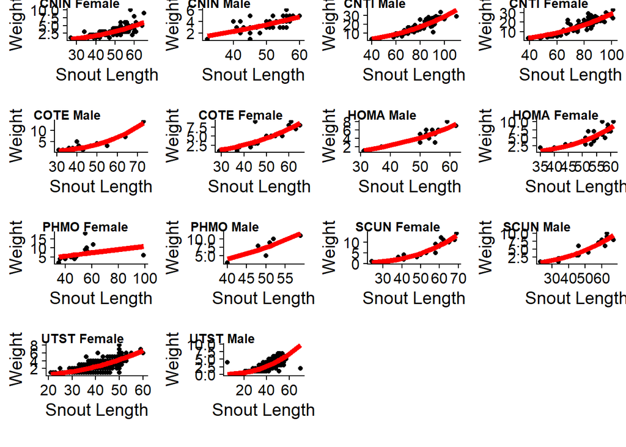

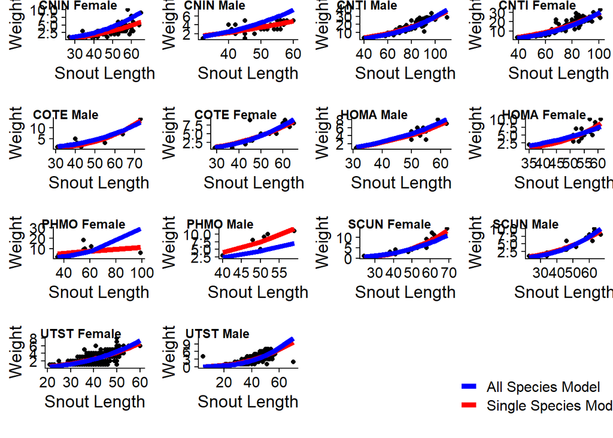

7. Calculate the percent difference in the $b$ parameter between male and females. Plot the differences as a graph. Describe the implications of your result.

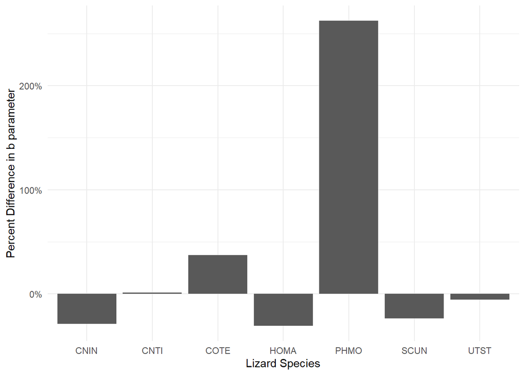

Comparing the two graphs the possible importance, but also the strength of nls. In the datasets with limited data, the model predictions are the most different as well as the parameters (see PHMO species). The species I choose by chance is nearly identical in parameter values between males and females as well as being almost perfectly correlated with the total nls model. I was trying to demonstrate that if we have enough information on the species it might be best to run a nls just on that species. If we have a new species though, the model is still pretty predictive so it depends on your confidence in identifying lizard species.